# **A decade of movement ecology**

Rocío Joo, Simona Picardi, Matthew E. Boone, Thomas A. Clay, Samantha C. Patrick, Vilma Romero and Mathieu Basille

[figure not shown]

1. **An abstract of the manuscript** (in this page!)
2. Data collection and processing (including links to codes in R)
3. Data analysis (including figures, tables and links to R codes)
4. Manuscript figures and tables (including codes in R)
5. Supplementary figures and tables (including codes in R)
6. Survey about the field of movement ecology applied to movement ecologists
7. R session information

## 1. Abstract of the manuscript

Movement is fundamental to life, shaping population dynamics, biodiversity, and ecosystem structure. Recent advances in tracking technology have enabled fundamental questions about movement to be tackled, and the number of publications in movement ecology has increased considerably over time. A decade ago, a framework was proposed for the study of movement ecology, as a first step for an integrative theory of organism movement (Nathan et al. 2008). This movement ecology framework (MEF), published in a PNAS’ special feature on movement ecology, has been recognized in the literature as a milestone in the field. Ten years after the publication of the MEF, we investigated the state of research in movement ecology. In this work, we show a snapshot of the field and its research topics, evaluate the impact of the MEF in the literature, and assess changes in the use of technological devices, software and statistical methods. To accomplish this task, we used a text mining approach to review > 8000 movement ecology published papers. We found that, while there have been major technological changes in the decade (i.e. more use of GPS devices, accelerometers and video cameras, and a convergence towards the use of R), the focus remains on the same research questions, and more specifically, on the effect of external factors such as the environment on movement and behavior. In practice, the comprehensive approach from the MEF has not been integrated into movement ecology research. Based on these results, we discuss the future of movement ecology, whether if technology will continue to be the driving force in the field, or if the field will rather transform, embrace the MEF and face the challenges of interdisciplinarity.

Nathan, R., Getz, W. M., Revilla, E., Holyoak, M., Kadmon, R., Saltz, D., & Smouse, P. E. (2008). A movement ecology framework for unifying organismal movement research. PNAS, 105(49), 19052–19059.

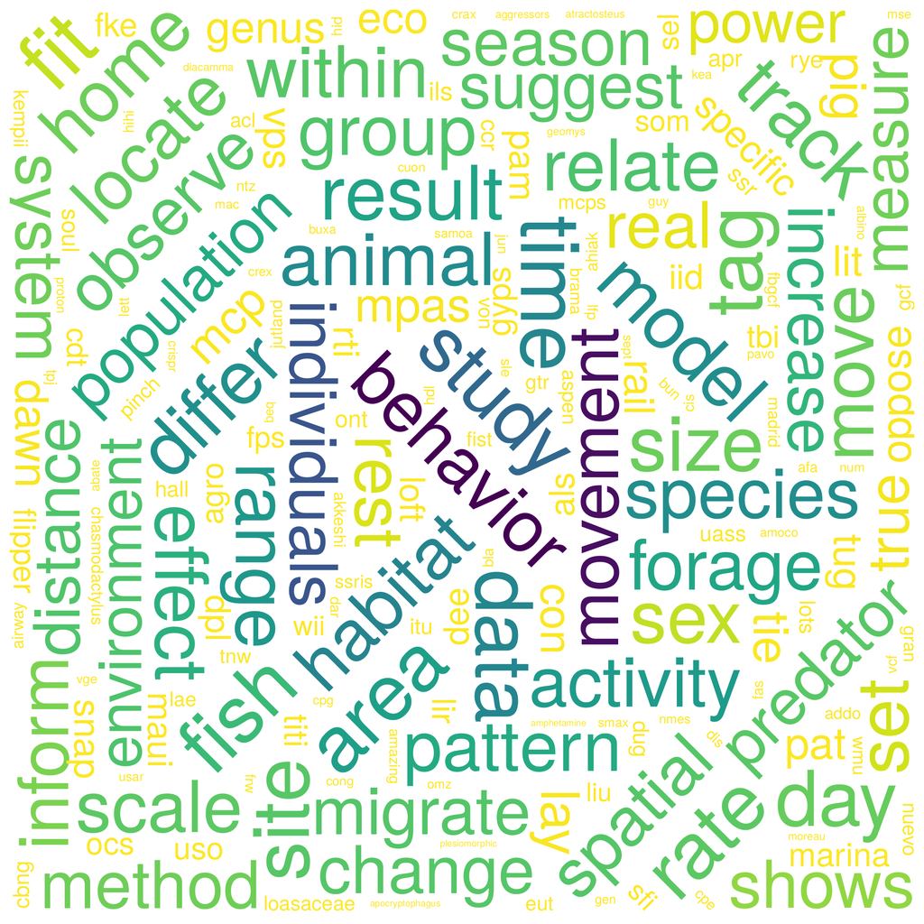